# homework #10

Maryam Nouri-Aiin

2024-04-07

```r
library(tidyverse)
library(dplyr)
library(ggplot2)
```

# For loops and randomization tests

Using a for loop, write a function to calculate the number of zeroes in a numeric vector. Before entering the loop, set up a counter variable counter <- 0. Inside the loop, add 1 to counter each time you have a zero in the vector. Finally, use return(counter) for the output.

```r
a <- sample(0:10, 100, replace = TRUE)

count_zeroes <- function(vec) {
  counter <- 0
  for (value in vec) {
    if (value == 0) {
      counter <- counter + 1
    }
  }
  return(counter)
}

count_zeroes (a)
```

```
## [1] 7
```

Use subsetting instead of a loop to rewrite the function as a single line of code.

```r
count_zeroes_vec <- function(vec) {
  sum(vec == 0)
}

count_zeroes_vec(a)
```

```
## [1] 7
```

```r
count_rows_cols <- function(df) {
  rows <- nrow(df)
  cols <- ncol(df)
  results <- matrix(c(rows, cols), nrow = 1, ncol = 2, dimnames = list(NULL, c("Rows", "Cols")))

  return(results)
}


df <- matrix(1:20, nrow = 5)  # example matrix
count_rows_cols(df)
```

```
##      Rows Cols
## [1,]    5    4
```

In the next few lectures, you will learn how to do a randomization test on your data. We will complete some of the steps today to practice calling custom functions within a for loop. Use the code from the March 31st lecture (Randomization Tests) to complete the following steps:

Simulate a dataset with 3 groups of data, each group drawn from a distribution with a different mean. The final data frame should have 1 column for group and 1 column for the response variable.

```r
set.seed(123)  # Ensure reproducibility
sim_dat <- function() {
  g1 <- rnorm(100, mean = 10)  # 100 observations from N(10, 1)
  g2 <- rnorm(100, mean = 15)  # 100 observations from N(15, 1)
  g3 <- rnorm(100, mean = 20)  # 100 observations from N(20, 1)
  data.frame(
    g = rep(1:3, each = 100),
    response = c(g1, g2, g3)
  )
}
data <- sim_dat()  # function is defined and generates initial data
```

Write a custom function that 1) reshuffles the response variable, and 2) calculates the mean of each group in the reshuffled data. Store the means in a vector of length 3.

```r
reshuf_and_mean <- function(data) {
  shuffled <- sample(data$response)
  data$shuffled <- shuffled
  aggregate(shuffled ~ g, data, mean)
}
```

Use a for loop to repeat the function in b 100 times. Store the results in a data frame that has 1 column indicating the replicate number and 1 column for each new group mean, for a total of 4 columns.

```r
repeat_reshuf <- function(data, n = 100) {
  results <- matrix(nrow = n, ncol = 3)
  for (i in 1:n) {
    means <- reshuf_and_mean(data)$shuffled
    results[i, ] <- means
  }
  results_df <- as.data.frame(results)
  names(results_df) <- c("Mean_g1", "Mean_g2", "Mean_g3")
  results_df$Replicate <- 1:n
  return(results_df)
}
reshufd_means_df <- repeat_reshuf(data, 100)
reshufd_means_long <- reshape2::melt(reshufd_means_df, id.vars = "Replicate")
```

Use qplot() to create a histogram of the means for each reshuffled group. Or, if you want a challenge, use ggplot() to overlay all 3 histograms in the same figure. How do the distributions of reshuffled means compare to the original means?

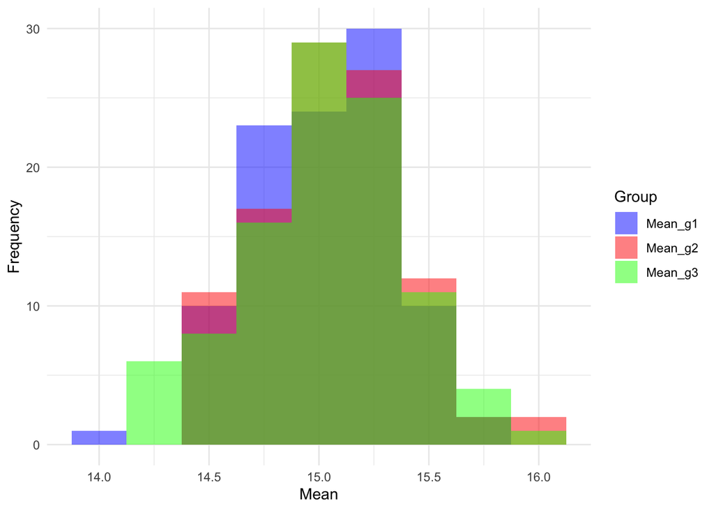

```r
ggplot(reshufd_means_long, aes(x = value, fill = variable)) +
  geom_histogram(alpha = 0.5, position = "identity", binwidth = 0.25) +
  labs(x = "Mean", y = "Frequency") +
  theme_minimal() +
  scale_fill_manual(values = c("blue", "red", "green")) +
  guides(fill=guide_legend(title="Group"))
```